# Guided Project: Scales and Facets

CIS-3901 · Module 13

Author

Dawson Raynes

Published

November 17, 2026

**ImportantThis copy includes the R code directly in the report.**

This is a standalone copy of the report with code from `scripts/gp13_scales_facets.R` inserted into the corresponding chunks. Changes to that script will not automatically update this report copy.

## My data

My fairness dataset is the Adult Income Dataset. One row is one person, with 5000 total rows. My sports dataset is the Marathon Race Results Dataset. One row is one runner, with 26598 total rows.

```r
put_in_place("fairness.csv")
put_in_place("sports.csv")

fairness <- read_csv("data/fairness.csv", show_col_types = FALSE)
sports <- read_csv("data/sports.csv", show_col_types = FALSE)

if (looks_damaged(fairness) || looks_damaged(sports)) {
  stop("One of your data files looks damaged (each row in one column): it ",
       "may have been re-saved by a spreadsheet app. Ask your instructor ",
       "for a fresh copy.", call. = FALSE)
}

# Your columns ("values" = how many different values: 2 to 4 suits
# task 5). Never put a column of people's names in a plot.
show_columns(fairness)
```

```
# A tibble: 15 × 4
   column         type      values missing
   <chr>          <chr>      <int>   <int>
 1 person_id      numeric     5000       0
 2 age            numeric       70       0
 3 workclass      character      8     290
 4 education      character     16       0
 5 education_num  numeric       16       0
 6 marital_status character      7       0
 7 occupation     character     15     290
 8 relationship   character      6       0
 9 race           character      5       0
10 sex            character      2       0
11 capital_gain   numeric       80       0
12 capital_loss   numeric       62       0
13 hours_per_week numeric       77       0
14 native_country character     41      93
15 income         character      2       0
```

```r
show_columns(sports)
```

```
# A tibble: 15 × 4
   column             type      values missing
   <chr>              <chr>      <int>   <int>
 1 age_group          character     10       0
 2 place_overall      numeric    26598       0
 3 place_gender       numeric    15176       0
 4 place_division     numeric     5285       0
 5 name               character  26324       0
 6 team               character     86       0
 7 bib_number         character  26598       0
 8 half_time          character   5062      72
 9 finish_net         character   9156       0
10 finish_gun         character   9355       0
11 gender             character      2       0
12 half_time_sec      numeric     5062      72
13 finish_net_sec     numeric     9156       0
14 finish_gun_sec     numeric     9355       0
15 finish_net_minutes numeric     9156       0
```

```r
# PART A · FAIRNESS ==========================================================

# A0 · See it update ---------------------------------------------------------
# A ready count plot of one of your Fairness columns. Nothing to code.
# YOUR TURN (kickoff): change one word in the title, then render the report
# and the slides, and find your word on both pages.
```

## Part A · Fairness

### A0 · See it update

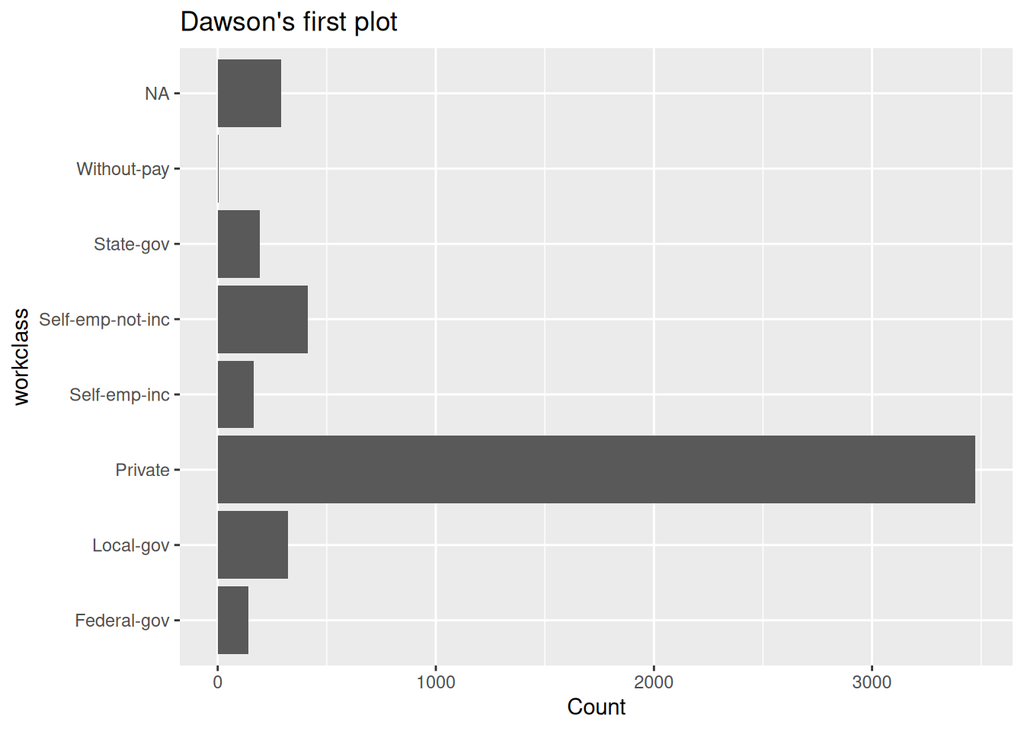

Figure 1: My first plot: a count of one of my Fairness columns.

```r
a0_column <- pick_a_column(fairness)

a0 <- ggplot(fairness, aes(y = .data[[a0_column]])) +
  geom_bar() +
  labs(title = "Dawson's first plot", x = "Count", y = a0_column)

show_plot(a0)
```

Yes, the updated title appeared in the report and slides.

### A1 · Label it

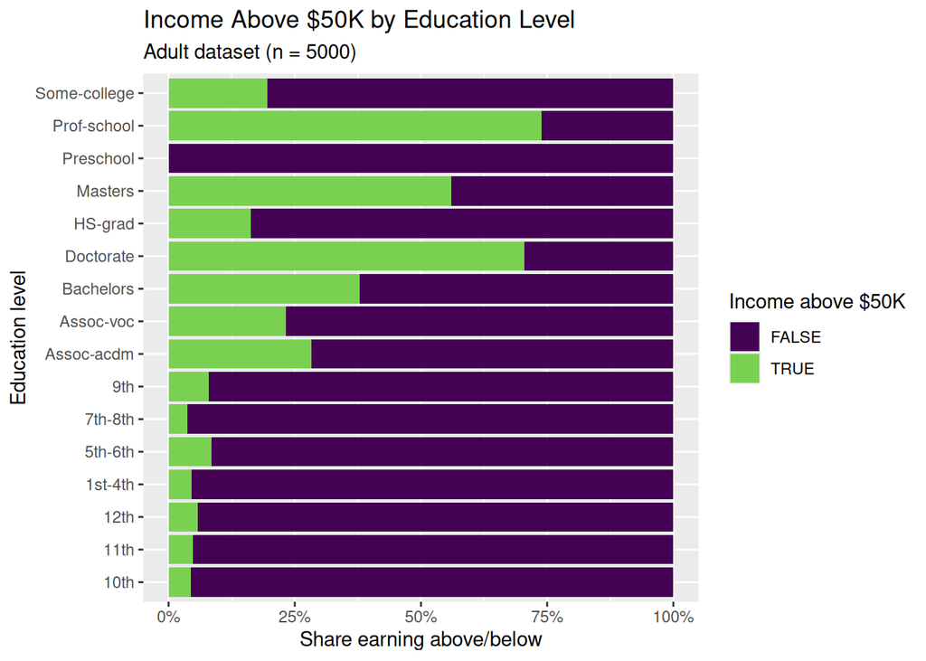

Figure 2: Share of each group with the outcome, labeled for a reader.

```r
a_data <- fairness %>%
  mutate(
    group = education,
    has_outcome = income == ">50K"
  )

a1_base <- ggplot(a_data, aes(y = group, fill = has_outcome)) +
  geom_bar(position = "fill")

a1 <- a1_base +
  labs(
    title = "Income Above $50K by Education Level",
    subtitle = "Adult dataset (n = 5000)",
    x = "Share earning above/below",
    y = "Education level",
    fill = "Income above $50K"
  ) +
  scale_x_continuous(labels = scales::percent)

show_plot(a1)
```

I changed the x-axis label the most because I wanted to make it clear that the percentages represent income categories within each education group. I think a reader could understand the plot without an explanation because the title, axes, and legend describe what is being compared.

### A2 · Choose a scale

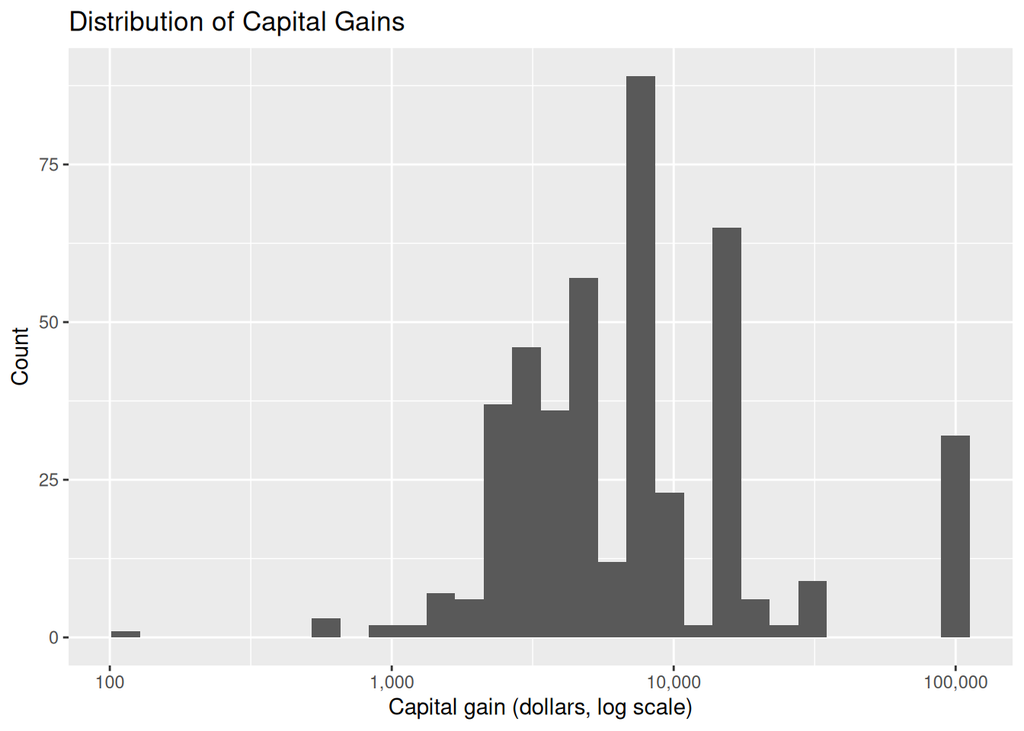

Figure 3: My scale choice.

```r
a2 <- fairness %>%
  filter(capital_gain > 0) %>%
  ggplot(aes(x = capital_gain)) +
  geom_histogram(bins = 30) +
  scale_x_log10(labels = scales::comma) +
  labs(
    title = "Distribution of Capital Gains",
    x = "Capital gain (dollars, log scale)",
    y = "Count"
  )

a2_reason <- "With linear scale, the graph would be skewed to the right, making
the values hard to see"

show_plot(a2)
```

I used a logarithmic scale for capital gain because most values are small, while some are much larger. Compared with a linear scale, the log scale makes the differences among smaller positive values easier to see. I excluded 4563 zero or negative values because they cannot be displayed on a logarithmic scale.

### A3 · Facet it: fixed or free

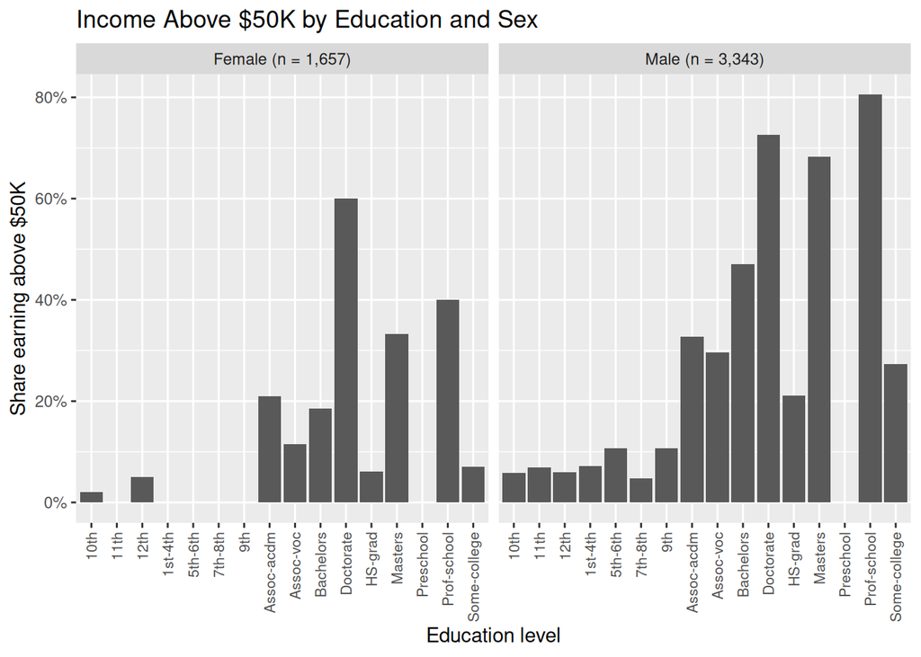

(a) Fixed

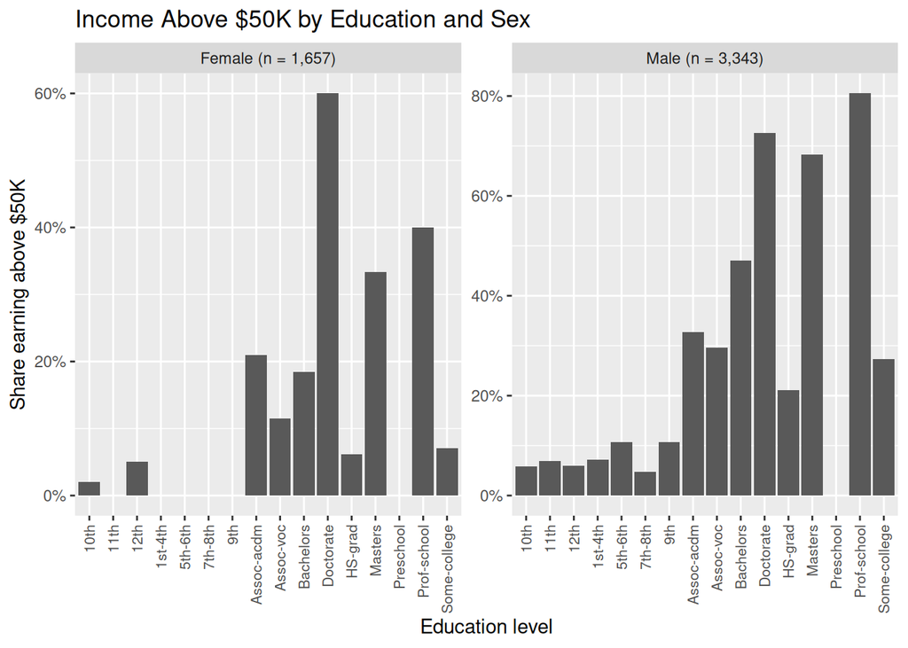

(b) Free

Figure 4: The same rates in panels: fixed and free y-axes.

```r
# YOUR TURN 1: replace "replace me" with your second column (no quotes).
a3_rates <- a_data %>%
  mutate(panel = sex) %>%
  drop_na(has_outcome) %>%
  add_count(panel, name = "panel_n") %>%
  mutate(panel = paste0(panel, " (n = ", scales::comma(panel_n), ")")) %>%
  group_by(panel, group) %>%
  summarize(n = n(), rate = mean(has_outcome), .groups = "drop")

a3_fixed <- ggplot(a3_rates, aes(x = group, y = rate)) +
  geom_col() +
  facet_wrap(vars(panel)) +
  scale_y_continuous(labels = scales::percent) +
  labs(
    title = "Income Above $50K by Education and Sex",
    x = "Education level",
    y = "Share earning above $50K"
  ) +
  theme(
    axis.text.x = element_text(angle = 90, hjust = 1, vjust = 0.5, size = 8)
  )

a3_free <- a3_fixed +
  facet_wrap(vars(panel), scales = "free_y")

# YOUR TURN 2: remove the # signs below, then replace each ___.
# a3_fixed <- ggplot(a3_rates, aes(x = group, y = rate)) +
#   geom_col() +
#   facet_wrap(vars(panel)) +
#   scale_y_continuous(labels = scales::percent) +
#   labs(title = "___", x = "___", y = "___ (%)")
# a3_free <- a3_fixed +
#   facet_wrap(vars(panel), scales = "free_y")

# YOUR TURN 3: which one would you publish, "fixed" or "free_y"? Why?
a3_choice <- "fixed"
a3_reason <- "Fixed scales make it easier to compare the percentage earning
above $50K between sex categories because both panels use the same y-axis."

show_plot(a3_fixed)
show_plot(a3_free)
```

Table 1: Each group’s n and rate, by panel.

| panel | group | n | rate |
| --- | --- | --- | --- |
| Female (n = 1,657) | 10th | 49 | 0.020 |
| Female (n = 1,657) | 11th | 53 | 0.000 |
| Female (n = 1,657) | 12th | 20 | 0.050 |
| Female (n = 1,657) | 1st-4th | 8 | 0.000 |
| Female (n = 1,657) | 5th-6th | 12 | 0.000 |
| Female (n = 1,657) | 7th-8th | 19 | 0.000 |
| Female (n = 1,657) | 9th | 19 | 0.000 |
| Female (n = 1,657) | Assoc-acdm | 62 | 0.210 |
| Female (n = 1,657) | Assoc-voc | 78 | 0.115 |
| Female (n = 1,657) | Bachelors | 276 | 0.185 |
| Female (n = 1,657) | Doctorate | 10 | 0.600 |
| Female (n = 1,657) | HS-grad | 519 | 0.062 |
| Female (n = 1,657) | Masters | 93 | 0.333 |
| Female (n = 1,657) | Preschool | 1 | 0.000 |
| Female (n = 1,657) | Prof-school | 15 | 0.400 |
| Female (n = 1,657) | Some-college | 423 | 0.071 |
| Male (n = 3,343) | 10th | 86 | 0.058 |
| Male (n = 3,343) | 11th | 115 | 0.070 |
| Male (n = 3,343) | 12th | 50 | 0.060 |
| Male (n = 3,343) | 1st-4th | 14 | 0.071 |
| Male (n = 3,343) | 5th-6th | 47 | 0.106 |
| Male (n = 3,343) | 7th-8th | 63 | 0.048 |
| Male (n = 3,343) | 9th | 56 | 0.107 |
| Male (n = 3,343) | Assoc-acdm | 104 | 0.327 |
| Male (n = 3,343) | Assoc-voc | 142 | 0.296 |
| Male (n = 3,343) | Bachelors | 582 | 0.471 |
| Male (n = 3,343) | Doctorate | 51 | 0.725 |
| Male (n = 3,343) | HS-grad | 1102 | 0.211 |
| Male (n = 3,343) | Masters | 173 | 0.682 |
| Male (n = 3,343) | Preschool | 5 | 0.000 |
| Male (n = 3,343) | Prof-school | 77 | 0.805 |
| Male (n = 3,343) | Some-college | 676 | 0.274 |

I chose fixed scales because they make it easier to compare income percentages between the panels. The reader gains a consistent scale for comparison, but smaller differences within a panel may be harder to see than with free scales. The percentages vary across education levels and between the sex categories. The smallest education-by-sex group, which is preschool-female, has only one observation, so its percentage should be interpreted cautiously.

### A4 · Compared to what?

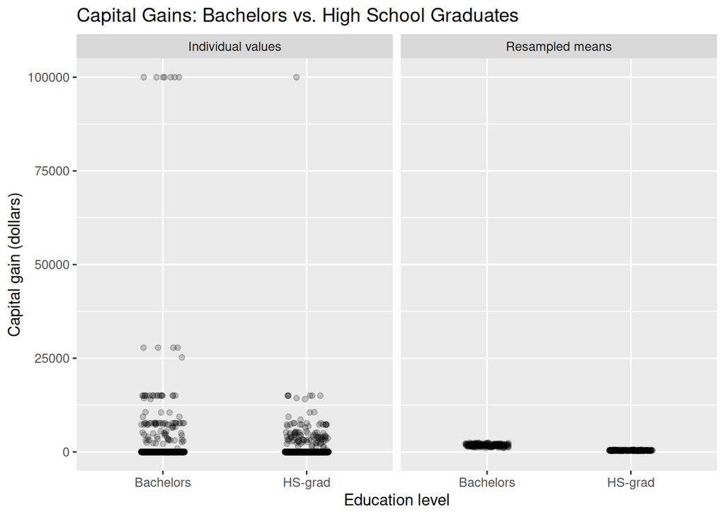

Figure 5: Two groups: individual values and resampled means, same axes.

```r
a4_clouds <- a_data %>%
  filter(education %in% c("Bachelors", "HS-grad")) %>%
  make_clouds(education, capital_gain)
# YOUR TURN 1: remove the # signs below, then replace each ___: the column
# with your groups, two of its values, and your numeric column.
# a4_clouds <- a_data %>%
#   filter(___ %in% c("___", "___")) %>%
#   make_clouds(___, ___)

a4 <- ggplot(a4_clouds, aes(x = group, y = value)) +
  geom_jitter(width = 0.15, height = 0, alpha = 0.2) +
  facet_wrap(~ kind) +
  labs(
    title = "Capital Gains: Bachelors vs. High School Graduates",
    x = "Education level",
    y = "Capital gain (dollars)"
  )
# YOUR TURN 2: remove the # signs below, then replace each ___.
# a4 <- ggplot(a4_clouds, aes(x = group, y = value)) +
#   geom_jitter(width = 0.15, height = 0, alpha = 0.2) +
#   facet_wrap(~ kind) +
#   labs(title = "___", x = "___", y = "___ (units)")

show_plot(a4)
```

The individual values show considerable overlap between the two education groups, with many people having little or no capital gain. The resampled means show how much the average could vary between samples. Comparing the panels helps distinguish differences between individual people from differences between group averages.

### A5 · Color for every reader

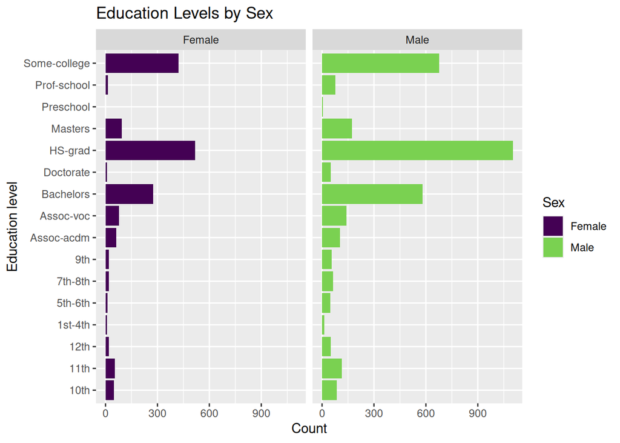

(a) My plot

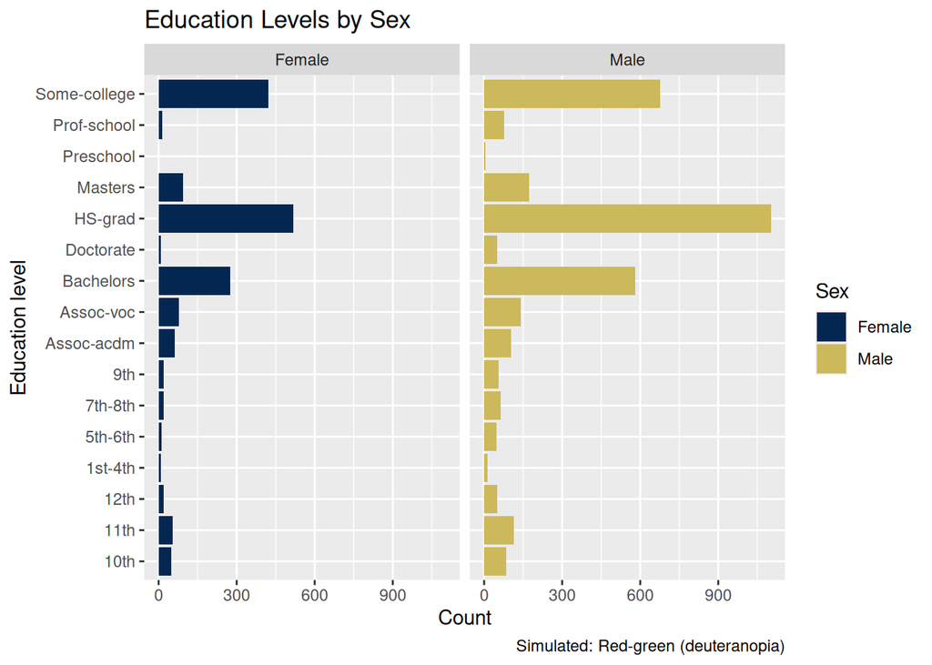

(b) Red-green (deuteranopia), simulated

Figure 6: My colors, with a second cue, and how a reader with red-green color blindness might see them.

```r
a5 <- ggplot(a_data, aes(y = education, fill = sex)) +
  geom_bar() +
  facet_wrap(~ sex) +
  scale_fill_viridis_d(end = 0.8) +
  labs(
    title = "Education Levels by Sex",
    x = "Count",
    y = "Education level",
    fill = "Sex"
  )

show_plot(a5)

# See it: your plot as a reader with red-green color blindness might see it.
show_plot(simulate_plot(a5, "Red-green (deuteranopia)"))
```

```r
color_check(a5)
```

```
2 colors. The red-green simulations come from a validated model;
the blue-yellow one is an approximation.
```

```
# A tibble: 3 × 3
  view                      smallest_difference at_least_20
  <chr>                                   <dbl> <chr>
1 Red-green (deuteranopia)                 99.5 Yes
2 Red-green (protanopia)                  119.  Yes
3 Blue-yellow (approximate)                81.3 Yes
```

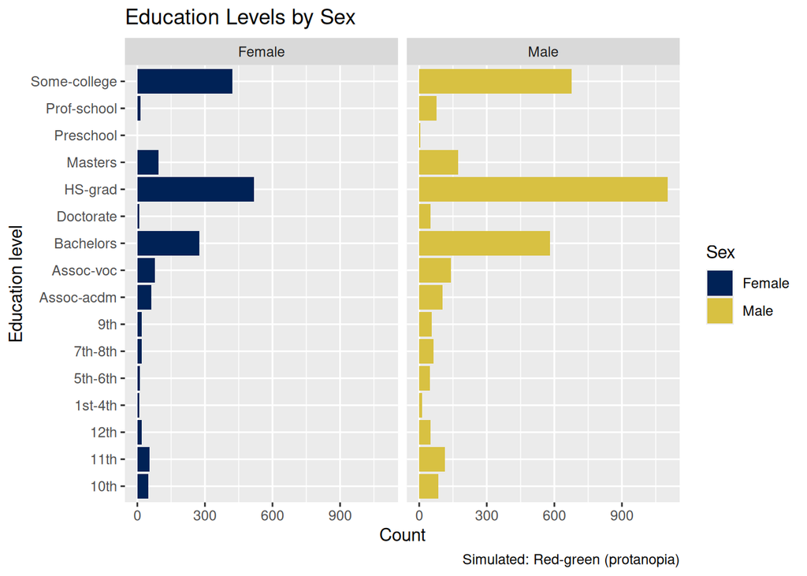

(a) Red-green (protanopia), simulated

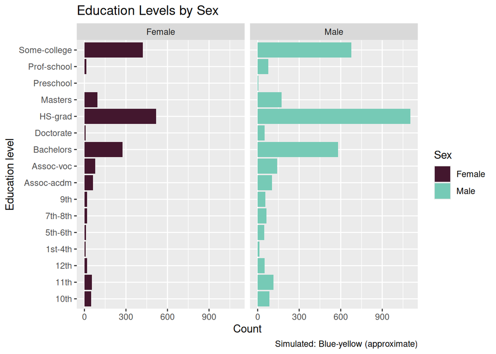

(b) Blue-yellow (approximate), simulated

Figure 7: The other two simulated views.

```r
show_plot(simulate_plot(a5, "Red-green (protanopia)"))
show_plot(simulate_plot(a5, "Blue-yellow (approximate)"))
```

I used the sex column for color because it has only a few categories, making the colors easier to distinguish. I chose a viridis color scale to improve accessibility for readers with color-vision differences. I also separated the categories into panels so readers do not have to rely on color alone. In the simulated views, the categories can still be identified using the panel labels.

## Part B · Sports

### B1 · Label it

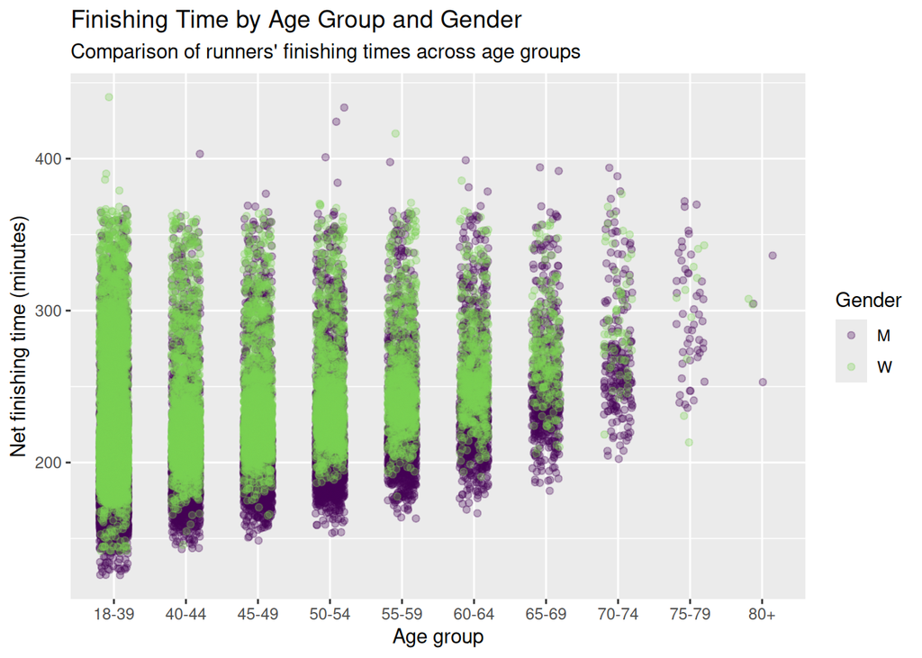

Figure 8: My Sports plot, labeled for a reader.

```r
b_data <- sports %>%
  mutate(
    group = age_group,
    has_outcome = place_overall <= 100,
    value = finish_net_minutes
  )

b1_base <- ggplot(b_data, aes(x = age_group, y = finish_net_minutes)) +
  geom_jitter(aes(color = gender), width = 0.2, height = 0, alpha = 0.3)

b1 <- b1_base +
  labs(
    title = "Finishing Time by Age Group and Gender",
    subtitle = "Comparison of runners' finishing times across age groups",
    x = "Age group",
    y = "Net finishing time (minutes)",
    color = "Gender"
  )

show_plot(b1)
```

The plot shows how runners’ finishing times vary across age groups and gender categories. I think the y-axis label is the most helpful because it explains that finishing times are measured in minutes.

### B2 · Choose a scale

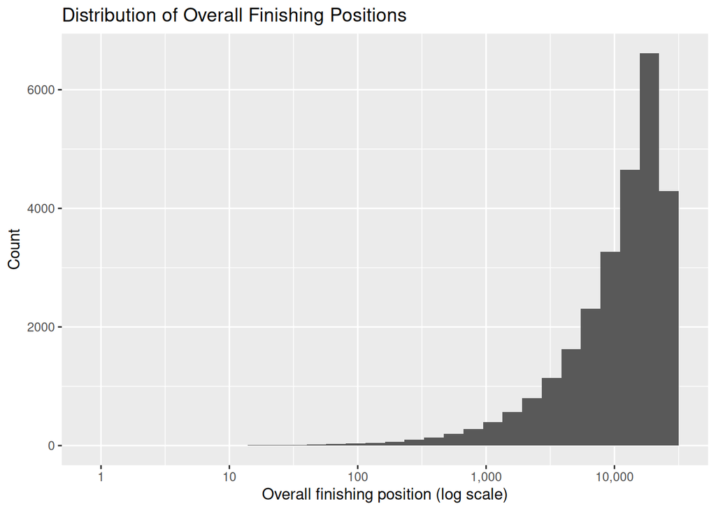

Figure 9: My scale choice.

```r
b2 <- b_data %>%
  filter(place_overall > 0) %>%
  ggplot(aes(x = place_overall)) +
  geom_histogram(bins = 30) +
  scale_x_log10(labels = scales::comma) +
  labs(
    title = "Distribution of Overall Finishing Positions",
    x = "Overall finishing position (log scale)",
    y = "Count"
  )

b2_reason <- "With a linear scale, basically everything is at the same level and
the points where it actually changes get smushed and aren't readable data."

show_plot(b2)
```

I used a logarithmic scale for overall finishing position to display a wide range of ranks. This spreads out the lower ranks and compresses the higher ranks, making the earlier finishing positions easier to distinguish. No zero or negative finishing positions were removed.

### B3 · Facet it: fixed or free

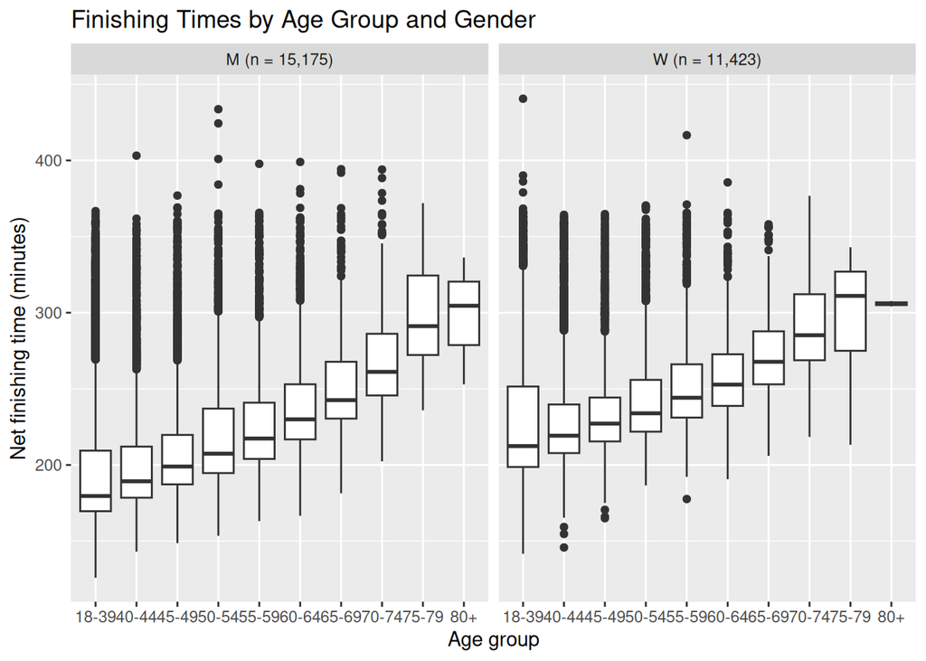

(a) Fixed

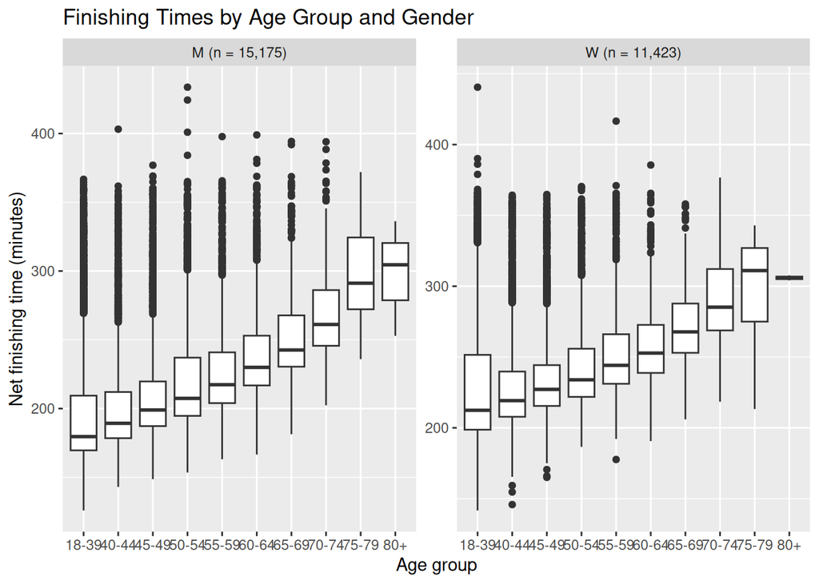

(b) Free

Figure 10: The same plot in panels: fixed and free y-axes.

```r
b3_data <- b_data %>%
  drop_na(gender, age_group, finish_net_minutes) %>%
  add_count(gender, name = "panel_n") %>%
  mutate(
    panel = paste0(gender, " (n = ", scales::comma(panel_n), ")")
  )

b3_fixed <- ggplot(
  b3_data,
  aes(x = age_group, y = finish_net_minutes)
) +
  geom_boxplot() +
  facet_wrap(vars(panel)) +
  labs(
    title = "Finishing Times by Age Group and Gender",
    x = "Age group",
    y = "Net finishing time (minutes)"
  )

b3_free <- b3_fixed +
  facet_wrap(vars(panel), scales = "free_y")

b3_choice <- "fixed"

b3_reason <- "A fixed scale makes it much easier to compare the finishing times
across gender groups."

show_plot(b3_fixed)
show_plot(b3_free)
```

I chose fixed scales because they allow finishing times to be compared directly between the gender panels. The reader gains a consistent y-axis, although differences within each panel may be less noticeable than with free scales. The boxplots show how finishing times vary across age groups and gender categories. The smaller panel contains 11423 runners, which is important to consider when comparing the groups.

### B4 · Compared to what?

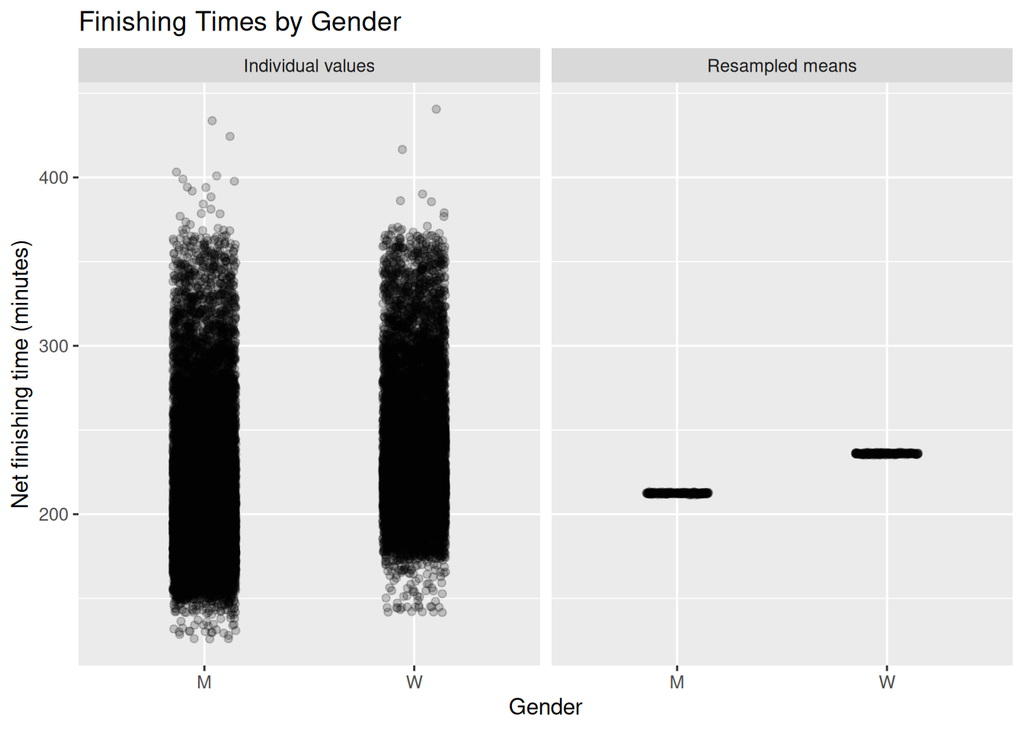

Figure 11: Two groups: individual values and resampled means, same axes.

```r
b4_clouds <- b_data %>%
  filter(gender %in% c("M", "W")) %>%
  make_clouds(gender, finish_net_minutes)

b4 <- ggplot(b4_clouds, aes(x = group, y = value)) +
  geom_jitter(width = 0.15, height = 0, alpha = 0.2) +
  facet_wrap(~ kind) +
  labs(
    title = "Finishing Times by Gender",
    x = "Gender",
    y = "Net finishing time (minutes)"
  )

show_plot(b4)
```

The individual finishing times show variation within both gender groups, with runners from both groups having overlapping finishing times. The resampled means show how much the average finishing time could vary between samples. This helps distinguish differences between individual runners from differences between the group averages.

### B5 · Color for every reader

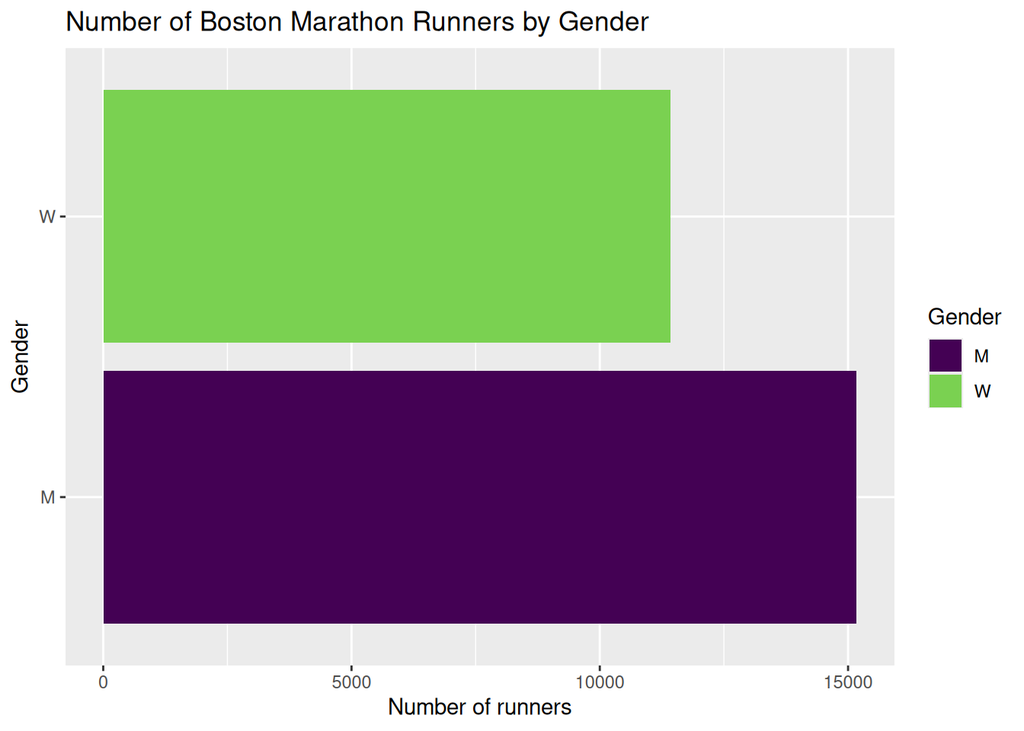

(a) My plot

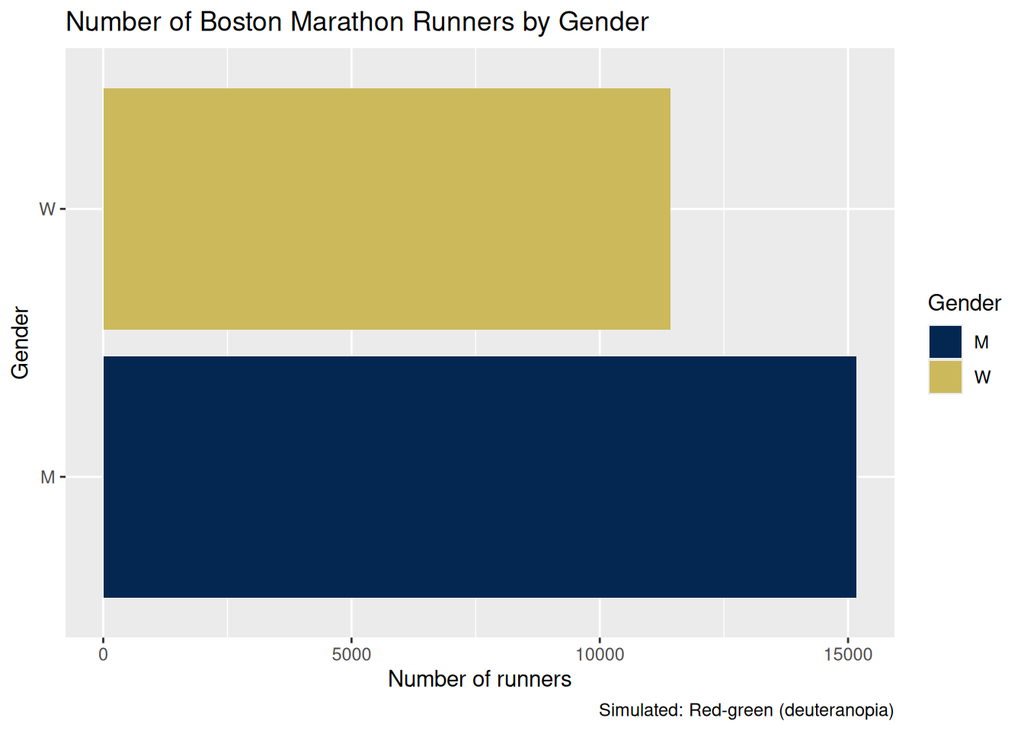

(b) Red-green (deuteranopia), simulated

Figure 12: My colors, with a second cue, and how a reader with red-green color blindness might see them.

```r
b5 <- ggplot(b_data, aes(y = gender, fill = gender)) +
  geom_bar() +
  scale_fill_viridis_d(end = 0.8) +
  labs(
    title = "Number of Boston Marathon Runners by Gender",
    x = "Number of runners",
    y = "Gender",
    fill = "Gender"
  )

show_plot(b5)

show_plot(simulate_plot(b5, "Red-green (deuteranopia)"))
```

```r
color_check(b5)
```

```
2 colors. The red-green simulations come from a validated model;
the blue-yellow one is an approximation.
```

```
# A tibble: 3 × 3
  view                      smallest_difference at_least_20
  <chr>                                   <dbl> <chr>
1 Red-green (deuteranopia)                 99.5 Yes
2 Red-green (protanopia)                  119.  Yes
3 Blue-yellow (approximate)                81.3 Yes
```

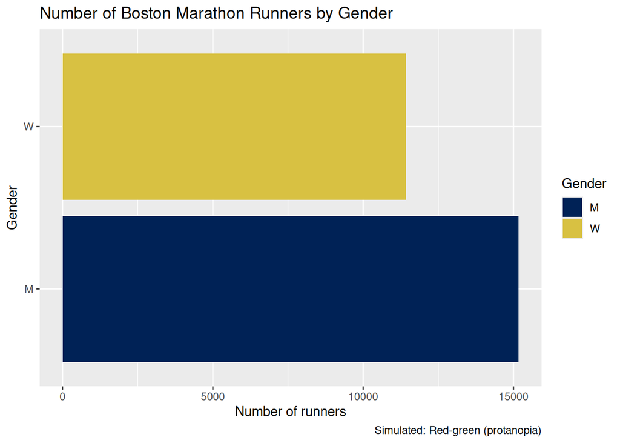

(a) Red-green (protanopia), simulated

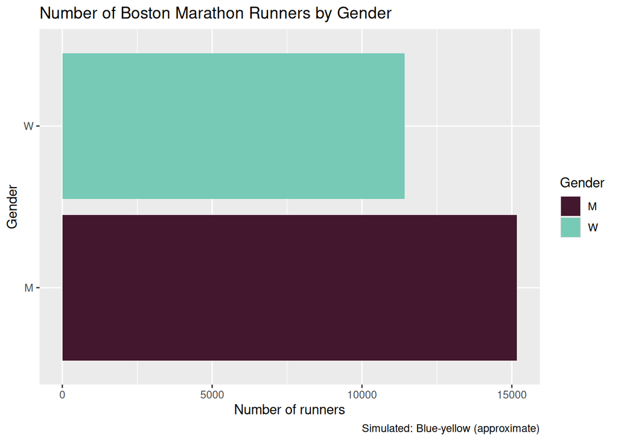

(b) Blue-yellow (approximate), simulated

Figure 13: The other two simulated views.

```r
show_plot(simulate_plot(b5, "Red-green (protanopia)"))
show_plot(simulate_plot(b5, "Blue-yellow (approximate)"))
```

I used gender for the fill colors because it has only a few categories, making the colors easier to distinguish. I chose the viridis color scale to improve accessibility for readers with color-vision differences. I also put gender on the y-axis so readers can identify the categories without relying only on color. The categories remain identifiable in the simulated views because of the axis labels.

## One thing I tried in my slides, and why

I focused my slides on income differences across education levels and sex categories. I used the fixed-scale version of my A3 plot so readers could compare percentages between the panels without having to account for different axis ranges. I also organized the slides so the research question comes before the main finding and the limitations come afterward.

## Revision log

Fill this in for the final: three to five changes to your report or slides. For each: what changed, why, and which idea from Module 14 it uses.

| Change | Why | Module 14 idea |
| --- | --- | --- |

## Checks

Table 2: Every task’s check, at the time this page was rendered.

| task | status |
| --- | --- |
| A0 | see the reminder |
| A1 | PASS |
| A2 | PASS |
| A3 | PASS |
| A4 | PASS |
| A5 | PASS |
| B1 | PASS |
| B2 | PASS |
| B3 | PASS |
| B4 | PASS |
| B5 | PASS |

## AI use

AI Use: None

## References

Becker, B. & Kohavi, R. (1996). Adult [Dataset]. UCI Machine Learning Repository. https://doi.org/10.24432/C5XW20

Fay, J., Dykstra, A. J., & Ramler, I. (2023, June 27). 2023 Boston Marathon runners [Data set]. SCORE Network. https://data.scorenetwork.org/data/boston_marathon_2023.csv